# Multi-level models

tadpole example from Rethinking

Alexander Massey

April 6, 2026

## Outline

1. The problem with independent group estimates
2. What is a multilevel model?
3. Mixed models: same idea, different language
4. Three estimators: complete pooling, no pooling, partial pooling
5. Bayesian hierarchical specification
6. Shrinkage and why it works
7. Today’s exercise

# Part 1

## The Core Problem

Suppose you observe survival rates across **48 tanks** of tadpoles.

Each tank has $n_i$ tadpoles and $s_i$ survivors.

**Two naive strategies:**

- Estimate each tank independently → noisy, overfits small tanks
- Pool all tanks together → ignores real variation between tanks

Neither extreme is satisfying. We need something in between.

## A Concrete Example

**Tank A:** 5 tadpoles, 5 survive  
$\hat{p} = 1.00$

**Tank B:** 5 tadpoles, 0 survive  
$\hat{p} = 0.00$

Should we really believe survival is **100%** or **0%** in these tanks?

. . .

Or is there **sampling noise** on top of a shared population process?

The key insight: tanks are not isolated experiments — they share a common biology.

# Part 2

## What Is a Multilevel Model?

A multilevel (hierarchical) model adds a **population distribution** over group-level parameters.

Instead of:

$$\alpha_{\text{tank}} \sim \text{Normal}(0,\ 5) \quad \text{(independent, fixed prior)}$$

We write:

$$\alpha_{\text{tank}} \sim \text{Normal}(\mu_\alpha,\ \sigma_\alpha) \quad \text{(shared population)}$$

$$\mu_\alpha \sim \text{Normal}(0, 1), \qquad \sigma_\alpha \sim \text{Half-Cauchy}(0, 1)$$

Now $\mu_\alpha$ and $\sigma_\alpha$ are **estimated from the data**.

## What This Buys Us

- **Regularization**: small tanks are pulled toward the population mean
- **Calibrated uncertainty**: wide $\sigma_\alpha$ → tanks really differ; small $\sigma_\alpha$ → pooling is justified
- **Honest inference**: we acknowledge that groups come from a common population

This is not a trick — it is the **correct generative model** when groups share a common process.

# Part 3

## Mixed Models: Same Idea, Different Language

Frequentist **linear mixed models** (LMMs) are hierarchical models in disguise.

In `lme4`:

```r
lmer(surv ~ 1 + (1 | tank), data = d)
```

This fits the same structure as our Bayesian model — a population-level intercept plus tank-level deviations.

So why the confusion?

## The Terminology Problem

| Frequentist LMM term | What it actually means |
| --- | --- |
| **Fixed effect** | Population-level parameter (estimated, interpreted directly) |
| **Random effect** | Group-level deviation from the population mean |
| **REML** | Restricted maximum likelihood — a bias correction for variance components; not a prior |
| **BLUPs** | Best linear unbiased predictors — empirical Bayes estimates of group-level effects |

“Fixed” and “random” do not mean what they sound like. The terminology predates modern statistical thinking and causes genuine confusion even among practitioners.

## Bayesian vs. Frequentist Framing

|  | Bayesian (brms) | Frequentist (lme4) |
| --- | --- | --- |
| Group intercepts | Parameters with a prior | “Random effects” — not full parameters |
| Population $\sigma$ | Posterior distribution | Point estimate via REML |
| Uncertainty | Full posterior | Confidence intervals (often approximate) |
| Interpretation | Direct probability statements | Repeated-sampling guarantees |

The **models are nearly identical**. The Bayesian framing is more explicit about what is being assumed. Also the prior helps with toxic cases like if all units in group are identical.

# Part 4

## Three strategies:

**Complete pooling** — All tanks share a single intercept
$$\text{logit}(p_i) = \alpha$$

**No pooling** — estimate each group independently
$$\text{logit}(p_i) = \alpha_{\text{tank}[i]}$$

**Partial Pooling** — share population distribution so information is “borrowed” across groups (shrinkage).

$$\begin{aligned} \text{logit}(p_i) &= \alpha_{\text{tank}[i]} \\ \alpha_{\text{tank}} &\sim \text{Normal}(\mu_{\alpha}, \sigma_{\alpha}) \\ \mu_{\alpha} &\sim \text{Normal}(0, 1.5) \\ \sigma_{\alpha} &\sim \text{Exponential}(1) \end{aligned}$$

## Three strategies:

**Complete pooling**

```r
# All tanks share a single intercept
brm(surv | trials(density) ~ 1,
    family = binomial, data = d)
```

**No pooling**

```r
brm(surv | trials(density) ~ 0 + tank,
    family = binomial, data = d)
```

**Partial Pooling**

```r
# Adaptive/Varying intercepts for tank
brm(surv | trials(density) ~ 1 + (1 | tank),
    data = d, family = binomial,
    prior = c(
      set_prior("normal(0, 1.5)", class = "Intercept"), # the default
      set_prior("exponential(1)", class = "sd")         # the default
    ))
```

## The Trade-off

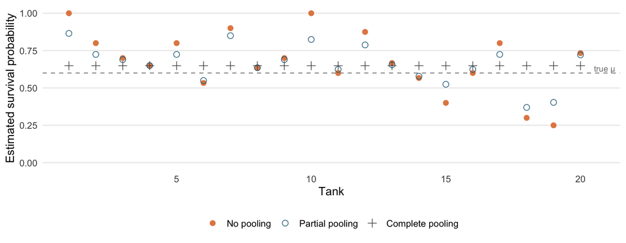

Partial pooling is **adaptive**: small tanks shrink more, large tanks shrink less.

# Part 5

## Specify full hierarchical Bayesian model:

**Level 1** — observation model (likelihood):

$$s_i \sim \text{Binomial}(n_i,\ p_i)$$

**Level 2** — group-level model:

$$\text{logit}(p_i) = \alpha_{\text{tank}_i}$$
$$\alpha_{\text{tank}} \sim \text{Normal}(\mu_\alpha,\ \sigma_\alpha)$$

**Level 3** — hyperpriors:

$$\mu_\alpha \sim \text{Normal}(0,\ 1)$$
$$\sigma_\alpha \sim \text{Half-Cauchy}(0,\ 1)$$

## In brms

**No-pooling model** — each tank gets an independent intercept:

```r
brm(surv | trials(density) ~ 0 + factor(tank),
    prior = prior(normal(0, 5), class = b),
    family = binomial, data = d)
```

**Partial-pooling model** — intercepts drawn from a population:

```r
brm(surv | trials(density) ~ 1 + (1 | tank),
    prior = c(prior(normal(0, 1), class = Intercept),
              prior(cauchy(0, 1), class = sd)),
    family = binomial, data = d)
```

The syntax `(1 | tank)` is borrowed from `lme4`. The prior on `class = sd` controls $\sigma_\alpha$ — **in the standard deviation metric**.

## Priors on the Variance Component

$\sigma_\alpha$ governs how much tanks vary. Two common choices:

**Half-Cauchy(0, 1)** — heavy tails, allows large between-group variation

$$\sigma_\alpha \sim \text{Half-Cauchy}(0,\ 1)$$

**Exponential(1)** — lighter tails, more skeptical of extreme variation

$$\sigma_\alpha \sim \text{Exponential}(1)$$

In practice, for well-identified problems with moderate group counts, the choice rarely matters much. **Check with a sensitivity analysis.**

# Part 6

## Shrinkage: Why It Works

When a tank has **few observations**, the likelihood is weak.

The population prior $\text{Normal}(\mu_\alpha, \sigma_\alpha)$ dominates → estimate pulled toward $\mu_\alpha$.

When a tank has **many observations**, the likelihood is strong.

The data dominate → estimate close to the observed proportion.

This is **automatic regularization** — no tuning parameter required. The degree of shrinkage is determined by the data through the estimated $\sigma_\alpha$.

## Shrinkage Reduces Error

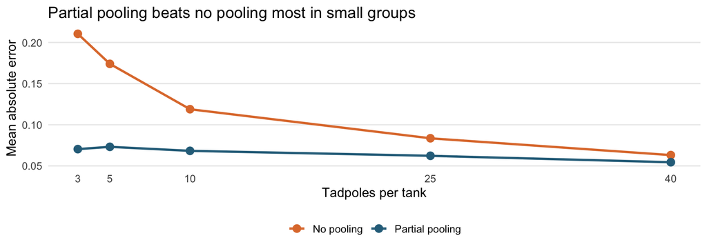

The advantage is largest for **small groups** and shrinks as within-group sample size grows.

## When Is Partial Pooling Worth It?

Partial pooling is most valuable when:

- Some groups have **few observations**
- Groups plausibly share a **common population process**
- You want to compensate for **compounding variables** implicitly
- You plan to **predict for new groups** not seen in training

It converges to complete pooling when $\hat{\sigma}_\alpha \to 0$, and to no pooling when $\hat{\sigma}_\alpha \to \infty$.

# Part 7

## Today’s Exercise

**Dataset:** Reed frog tadpole survival (`reedfrogs`, 48 tanks)

**Part 1 — Real data**

- Fit the no-pooling and partial-pooling binomial models
- Compare predictive accuracy with `loo_compare()`
- Visualize shrinkage of tank estimates

**Part 2 — Simulation study**

- Simulate 60 ponds with known true survival probabilities
- Compare all three estimators against ground truth
- Confirm that partial pooling dominates in small ponds

## Workflow for Each Model

For every model you fit today:

1. **Prior predictive check** — do prior draws look plausible?
2. **Fit the model** — `brm(...)`
3. **Convergence** — inspect $\hat{R}$, $N_{eff}$, trace plots
4. **Posterior predictive check** — does the model reproduce the data?
5. **Inference** — interpret parameters, plot effects

This workflow applies to every Bayesian model, not just multilevel ones. Make it a habit.

## Key Parameters to Interpret

From `print(model_brms)`:

- `b_Intercept` → $\mu_\alpha$, population-average log-odds of survival → back-transform: `plogis(b_Intercept)`
- `sd_tank__Intercept` → $\sigma_\alpha$, between-tank standard deviation on log-odds scale

From `coef(model_brms)$tank`:

- Tank-level posterior medians, partially pooled toward $\mu_\alpha$

From `loo_compare()`:

- `elpd_diff` — difference in expected log predictive density
- Rule of thumb: `|elpd_diff| > 2 × se_diff` → meaningful difference

## Summary

- Multilevel models share information across groups via a **population distribution**
- They are identical in structure to frequentist mixed models — the Bayesian framing is more explicit
- Frequentist terminology (fixed/random effects, REML) is a historical artifact; the Bayesian terms are clearer
- Partial pooling **adaptively regularizes**: more shrinkage for data-sparse groups
- In `brms`: `(1 | group)` specifies varying intercepts; prior on `class = sd` controls $\sigma_\alpha$

Open `multilevel_exercise.qmd`.

## References

- McElreath, R. (2020). *Statistical Rethinking*, 2nd ed. CRC Press. Chapter 13.
- Kurz, A. S. (2023). *Statistical Rethinking with brms, ggplot2, and the tidyverse*. https://bookdown.org/ajkurz/Statistical_Rethinking_recoded/
- Bürkner, P.-C. (2017). brms: An R package for Bayesian multilevel models using Stan. *Journal of Statistical Software*, 80(1), 1–28.
- Gelman, A. & Hill, J. (2007). *Data Analysis Using Regression and Multilevel/Hierarchical Models*. Cambridge University Press.
- Bates, D., Mächler, M., Bolker, B., & Walker, S. (2015). Fitting linear mixed-effects models using lme4. *Journal of Statistical Software*, 67(1), 1–48.